# Ford Go Bike 2019

## by Jawaher Alzahrani

## Investigation Overview

This project analyzes the distribution of trips of the bike-sharing system Ford Go Bike, in the San Francisco Bay Area, taken from June through December of 2019 (total of 183412 observations).

The objective is to perform an Exploratory Data Analysis in order to identify interesting insights, looking for patterns, relationships and correlations between all features.

I'm most interested in figuring out what features are best for predicting the duration of the trip in the dataset. and have some qusetion to help analysis:

1.What the most using of biking men or women ?

2.What is the average age of biking rider?

3.Dose duration trip effected by gender and age?

4.Does User Type (Subscriber or Customer) affect the duration?

5.What are the preferred days for gender and users type ?

## Dataset Overview

Ford GoBike System Data This data set includes information about individual rides made in a bike-sharing system covering the greater San Francisco Bay area.

There are 183412 records of trip in the dataset and Most variables are numeric in nature, but the variables user_type,station names are cateogrical in nature.  
This Dataset cincludes information about individual rides of users in San Francisco Bay Area with 15 features :-  
Trip Duration (seconds)  
Start Time and Date  
End Time and Date  
Start Station ID  
Start Station Name  
Start Station Latitude  
Start Station Longitude  
End Station ID  
End Station Name  
End Station Latitude  
End Station Longitude  
Bike ID  
User Type (Subscriber or Customer – “Subscriber” = Member or “Customer” = Casual)  
Member Year of Birth  
Member Gender  
bike_share_for_all_trip

## Distribution of duration Trip

This hist plot indicates we have outliers since we have values greater 3 hours on the x-axis.These values are not seen on the histplot.The code in the next slide shows the average minutes that spend user in trip between 10-12 minutes.

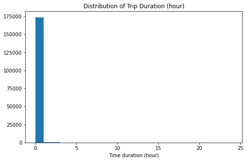

```python
# start with a standard-scaled plot
binsize = 1
bins = np.arange(0, df['duration_hour'].max()+binsize, binsize)
plt.figure(figsize=[8, 5])
plt.hist(data = df, x = 'duration_hour', bins = bins)
plt.xlabel('Time duration (hour)')
plt.title('Distribution of Trip Duration (hour)')
plt.show()
```

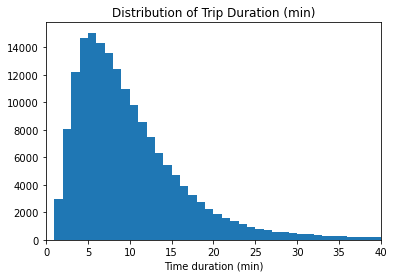

```python
bins = np.arange(0, df['duration_min'].max()+1, 1)
plt.hist(data = df, x = 'duration_min', bins = bins)
plt.xlim([0,40])
plt.xlabel('Time duration (min)')
plt.title('Distribution of Trip Duration (min)')
plt.show();
```

## Distribution of Member gender

This bar plot indicates we have 3 category of gender .It depicts the percentage of bike users 74.59 % male and 23.32% female ,This indicates that the most bike riders are Male.

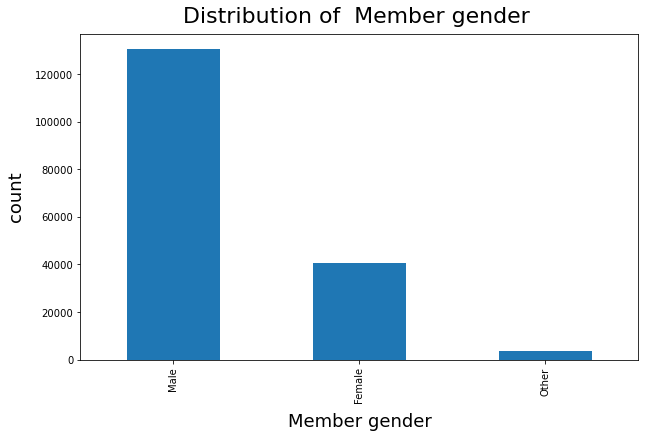

```python
plt.figure(figsize=(10,6))

gender= df['member_gender'].value_counts().plot.bar()
gender.set_xticklabels(['Male','Female' , 'Other'])
plt.title(' Distribution of  Member gender  ', fontsize=22, y=1.015)
plt.xlabel('Member gender', fontsize=18, labelpad=10)
plt.ylabel('count', fontsize=18, labelpad=10);
```

## The Average age distribution

This boxplot indicates the average of age who used bike between 33 to 35 years . we have outliers since we have values greater 100 years on the x-axis.

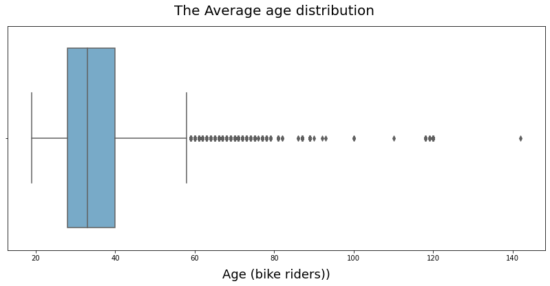

```python
plt.figure(figsize=(14,6))
sb.boxplot(x='member_age', data=df, palette='Blues', orient='h')
plt.title("The Average age distribution ", fontsize=20, y=1.03)
plt.xlabel("Age (bike riders))", fontsize=18, labelpad=10);
```

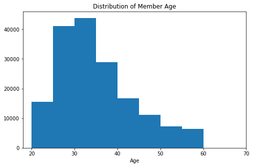

```python
# plot distribution of age
plt.figure(figsize = [8, 5])

binsize = 5
bins = np.arange(0, df2['member_age'].max()+binsize, binsize)

plt.hist(data = df2, x = 'member_age', bins = bins)
plt.xlim(18, 70)
plt.xlabel('Age')
plt.title('Distribution of Member Age')
plt.show()
```

## Relationship between gender and age

Relationships between gender and age bike riders, I used the boxplot to find the relationship between age and gender for bike riders as there is no significant difference, as the average age of females is 33 and men are 34 years.

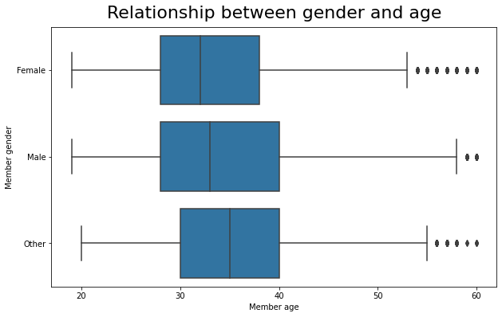

```python
plt.figure(figsize=(10,6))
base_color = sb.color_palette()[0]
sb.boxplot(data=df2, y='member_gender', x='member_age', color=base_color)
plt.title('Relationship between gender and age', fontsize=22, y=1.015)
plt.xlabel('Member age')
plt.ylabel('Member gender');
```

## Relationship between gender and user type

Relationships between gender and user_type bike riders, I used the countplot to find how many females and males there are in each user type.I find that customers type have the lowest percentage of subscribers type for both gender. And subscribers type were more men than women.

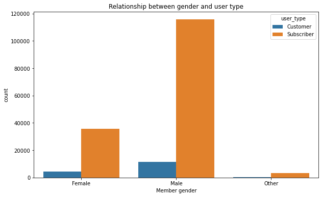

```python
plt.figure(figsize=(10,6))
sb.countplot(data = df2, x = 'member_gender', hue = 'user_type')
plt.title('Relationship between gender and user type')
plt.xlabel('Member gender')
plt.ylabel('count');
```

## Relationships between the duration trip (min) and the members ages

I want to see if there any relationships between the duration trip (minute) and the members ages by scatter plot but as we can see in the figure there is no positive or negative relationship and we don’t any relationship between them at all.

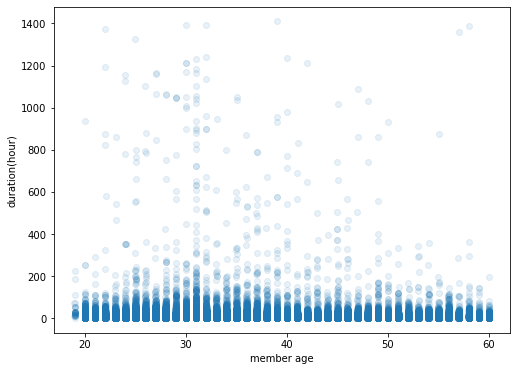

```python
plt.figure(figsize = [18, 6])

# PLOT ON LEFT
plt.subplot(1, 2, 1)
sb.regplot(data = df2, x = 'member_age', y = 'duration_min', x_jitter=0.04, scatter_kws={'alpha':1/10}, fit_reg=False)
plt.xlabel('member age')
plt.ylabel('duration(hour)');
```

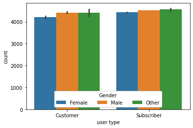

```python
ax = sb.barplot(data = df2, x = 'user_type', y = 'bike_id', hue = 'member_gender')
ax.legend(loc = 8, ncol = 3, framealpha = 1, title = 'Gender')
plt.xlabel('user type')
plt.ylabel('count');
```

## the point plot of day vs user type and day vs gender

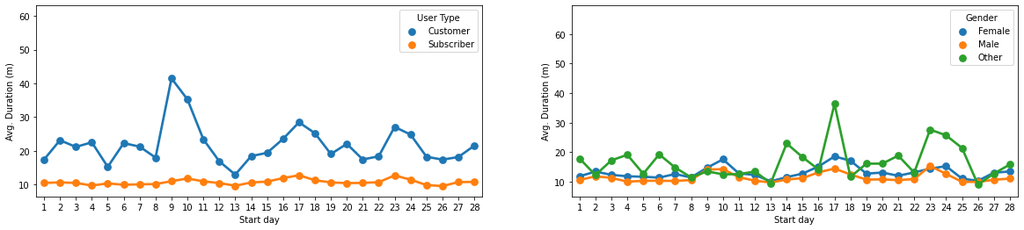

```python
plt.figure(figsize=[20, 4])

# the point plot of day vs user type
plt.subplot(1, 2, 1)
sb.pointplot(data=df2, x='start_date_day', y='duration_min', hue='user_type', errwidth=0)
plt.xlabel('Start day')
plt.ylabel('Avg. Duration (m)')
plt.legend(title='User Type')

# the point plot of day vs gender
plt.subplot(1, 2, 2)
sb.pointplot(data=df2, x='start_date_day', y='duration_min', hue='member_gender', errwidth=0)
plt.xlabel('Start day')
plt.ylabel('Avg. Duration (m)')
plt.legend(title='Gender');
```

```python
!jupyter nbconvert explanatory _fordgobike-Part2.ipynb --to slides --post serve --template output_toggle
```

[output not shown]

[output not shown]

[output not shown]

[output cut: 90 more lines]

[output not shown]